# Psy 350: HW 1

# Cleare environments

```r
rm(list=ls())
```

# load libraries

```r
library(psych)
```

# Read in data

```r
setwd("C:/Users/Neil/Desktop/Class folder/Fall 2018/Psy_350/Data")
Yetz.data <- read.csv("PSY 350 Class Survey.csv", header = TRUE, stringsAsFactors = FALSE)
```

# 1

## a.

What proportion of the class identifies as male, and what proportion identifies as female? What proportion did not identify as either male or female? Note that I am asking for proportions here â decimal values â not percentages or numbers of students.

```r
prop.table(table(Yetz.data$gender))
```

```
         f          m          o
0.81318681 0.16483516 0.02197802
```

Male = 16% Female = 81%

# 2

```r
table(Yetz.data$interest)
```

```
  clinical   cogneuro  cognitive  community counseling   forensic     health industrial      other     social     unsure
         6          7          2          1         27         13          6         10          8          5          6
```

## a

How many students in the class are primarily interested in counseling psychology? Here, I am asking you for a number

Counseling = 27

## b.

What are the three most popular areas of interest in psychology among the class?

Top = Counseling, forensic, industrial

## c.

What percentage of the class is still undecided about their primary interest area (that is, selected âunsureâ)?

```r
prop.table(table(Yetz.data$interest))
```

```
  clinical   cogneuro  cognitive  community counseling   forensic     health industrial      other     social     unsure
0.06593407 0.07692308 0.02197802 0.01098901 0.29670330 0.14285714 0.06593407 0.10989011 0.08791209 0.05494505 0.06593407
```

unsure = 7%

## d.

What R function did you use to calculate the previous answer?

prop.table()

# 3

## a.

Create a figure that represents the interest areas of the class. Take a screen shot and upload it.

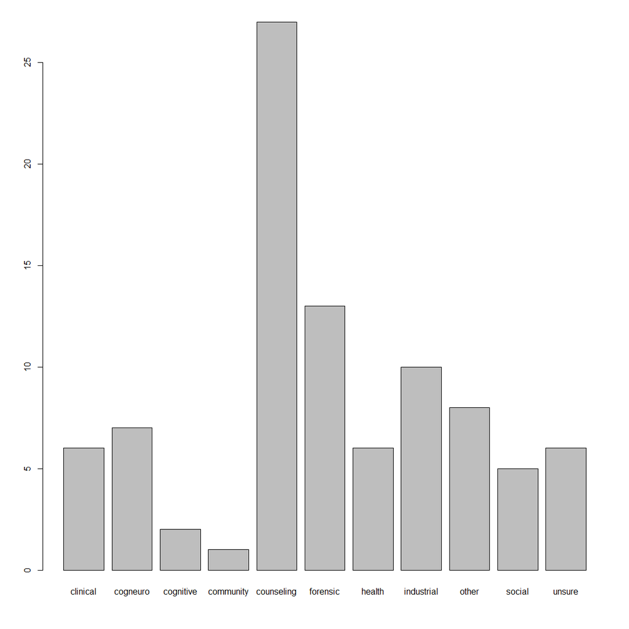

```r
bar <- table(Yetz.data$interest)
barplot(bar)
```

## b.

Is it more appropriate here to use a bar chart or a histogram?

barchart

## c.

Why?

Nominal Variables

# 4

## a.

What is the mean number of cups of coffee consumed by members of the class?

```r
describe(Yetz.data$coffee)
```

```
   vars  n mean   sd median trimmed  mad min max range skew kurtosis   se
X1    1 91 4.15 4.84      3    3.37 4.45   0  28    28  1.8     4.95 0.51
```

Mean = 4.15

## b.

What is the median?

Median = 3

## c.

What is the standard deviation for this variable?

SD = 4.84

# 5

## a.

Create an appropriate figure to represent the number of cups of coffee consumed by members of the class. Take a screen shot and upload it.

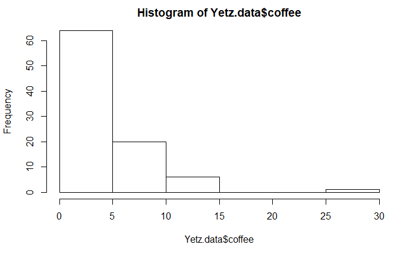

```r
hist(Yetz.data$coffee)
```

## b.

Is it more appropriate here to use a bar chart or a histogram?

Histogram

# 6.

## a.

Is the distribution of coffee consumption symmetric or skewed, based on the statistics and decision rules discussed in lecture and your text?

## b.

Explain how you know (report the numbers that support your conclusion). (1 point)

skew = 1.8 less than agreed 2+ for too much skew